# Numerical Methods for PDEs (Spring 2017), Lab 3

Richard Southwell, Gustav Delius

# Forward difference method

Consider the heat equation
$$u_{t}(x,t) = K u_{xx}(x,t), \quad
0<x< 1, \quad 0<t<0.1,$$
subject to the boundary conditions
$$u(0, t) = u(1, t)=0,$$
and initial condition
$$u(x, 0) = 2\sin(2\pi x).$$
Here $K > 0$ is the heat parameter. Let $N$ and $M$ be integers and let $h=1/N$
and $\tau=0.1/M$. Then we define the grid points $(x_k, t_j)$, where $x_k=hk$ for $k=0,1,\dots,N$ and $t_j=\tau j$ for $j=0,1,\dots,M$. The problem is to find numbers $w_{kj}$ such that $w_{kj}$ approximates the value of the exact solution $u(x,t)$ at the grid point $(x_k, t_j)$.

The forward-difference method to obtain a numerical approximation to this initial-value problem is
$$\begin{eqnarray}
&&w_{k,0}=u_{0}(x_{k}), \quad k=1, \dots, N-1; \nonumber \\
&&w_{0,j}=w_{N,j}=0, \quad j=0, 1, \dots, M; \nonumber \\
&&w_{k,j+1}=\left(1-2\gamma\right)w_{kj}+
\gamma\left(
w_{k+1, j}+w_{k-1,j}\right), \quad k=1, 2, \dots, N-1 \ \
{\rm and} \ \ j=0,1, \dots, M-1 . \nonumber
\end{eqnarray}$$

Here
$$\gamma=\frac{K \tau}{h^{2}}.$$

The method described above is called the forward-difference method. It can also be written in the matrix form
$${\bf w}^{(j)}=A{\bf w}^{(j-1)} \quad \hbox{for} \quad j=1,2,\dots, \label{b6}$$
where
$$A=\left[\begin{array}{cccccc}
1-2\gamma &\gamma &0 &\dots &\dots &0 \\
\gamma &1-2\gamma &\gamma &\ddots & &\vdots \\
0 &\gamma &1-2\gamma &\gamma &\ddots &\vdots \\
\vdots &\ddots &\ddots &\ddots &\ddots &0 \\
\vdots & &\ddots &\ddots &\ddots &\gamma \\
0 &\dots &\dots &0 &\gamma &1-2\gamma
\end{array}\right], \quad
{\bf w}^{(j)}
=\left[\begin{array}{c}
w_{1,j} \\
w_{2,j} \\
\vdots \\
\vdots \\
\vdots \\
w_{N-1,j}
\end{array}\right].$$

We shall gradually construct code to study this scenario.

We start by generating a vector $(x_1,x_2,..,x_{N-1})$ of non-boundary grid points. Here $x_k = hk$ where $h = L/N$ where $L=1$, and, for the sake of this example we choose $N=30$:

```r
N <- 30
L <- 1
h <- L/N
x <- h*(1:(N-1))
```

The initial condition ${\bf w}^{(0)}$ is specified as follows:

```r
w <- 2*sin(2*pi*x)
w
```

```
 [1]  4.158234e-01  8.134733e-01  1.175571e+00  1.486290e+00  1.732051e+00
 [6]  1.902113e+00  1.989044e+00  1.989044e+00  1.902113e+00  1.732051e+00
[11]  1.486290e+00  1.175571e+00  8.134733e-01  4.158234e-01  2.449213e-16
[16] -4.158234e-01 -8.134733e-01 -1.175571e+00 -1.486290e+00 -1.732051e+00
[21] -1.902113e+00 -1.989044e+00 -1.989044e+00 -1.902113e+00 -1.732051e+00
[26] -1.486290e+00 -1.175571e+00 -8.134733e-01 -4.158234e-01
```

Next we set up the time stepping. The amount of time our system runs for is $T=0.1.$ In this case let us use $M = 200$ time steps. The time step size is $\tau = \frac{T}{M}$. This enables us to define the vector `t` of time steps.

```r
T <- 0.1
M <- 200
tau <- T/M
t <- tau*(0:M)
```

In this example we shall set the heat parameter to be $K=1,$ and so we can specify the value of $\gamma = \frac{K \tau }{h^2}.$

```r
K <- 1
gamma <- K*tau/(h^2)
```

Given an R variable `w` that represents the system state ${\bf w}^{(j)},$ on time step $j$, if we want to update, to determine the system state ${\bf w}^{(j+1)},$ on the next time step, then we multiply `w` by the matrix `A` defined by the code:

```r
A <- diag(1-2*gamma, N-1)
for (k in 1:(N-2)) {
    A[k,k+1] <- gamma
    A[k+1,k] <- gamma
}
```

We perform such an update in R by computing the matrix product `A %*% w` of `A` and `w`. We use this method to plot ${\bf w}^{0}$ and ${\bf w}^{1}$ in the following code:

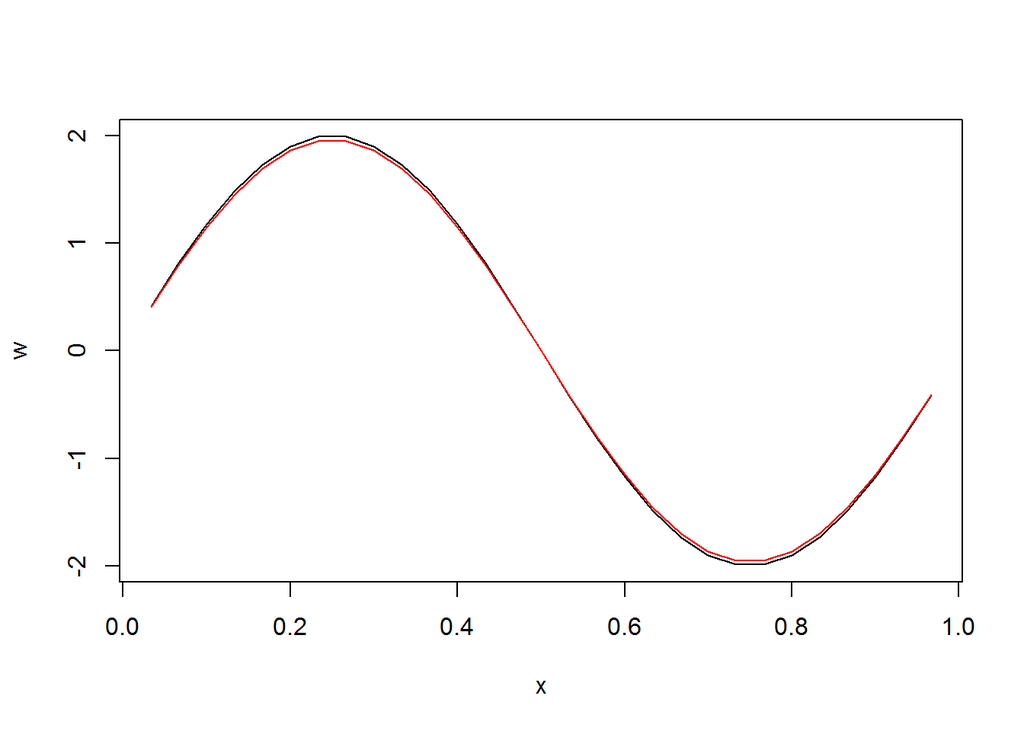

```r
plot(x, w, type = "l")
lines(x, A %*% w, col = "red")
```

Note how the solution has changed ever so slightly over this one time step.

In order to evolve our system over all `M` time steps, we repeatedly rewrite the object `w` by its updated value `A %*% w`, by using the command `w <- A %*% w`, inside a do loop. As we do this we store the successive vectors ${\bf w}^{0}, {\bf w}^{1},..,{\bf w}^{M}$, as successive columns of an $(N-1) \times (M+1)$ matrix which we call `Temperature`. Initially we define this matrix as being full of zeroes. All this is done in the following code:

```r
Temperature <- matrix(0, N-1, M+1) # Matrix to hold the solution
Temperature[ , 1] <- w
# Loop over time steps
for (j in 0:M) {
    w <- A %*% w
    Temperature[ , j+1] <- w
}
```

Note we added comments to the code using `#`. Everything on a line after a `#` will be ignored by R and is there to help the human reader.

We shall make a 3D plot to show the time evolution of our system:

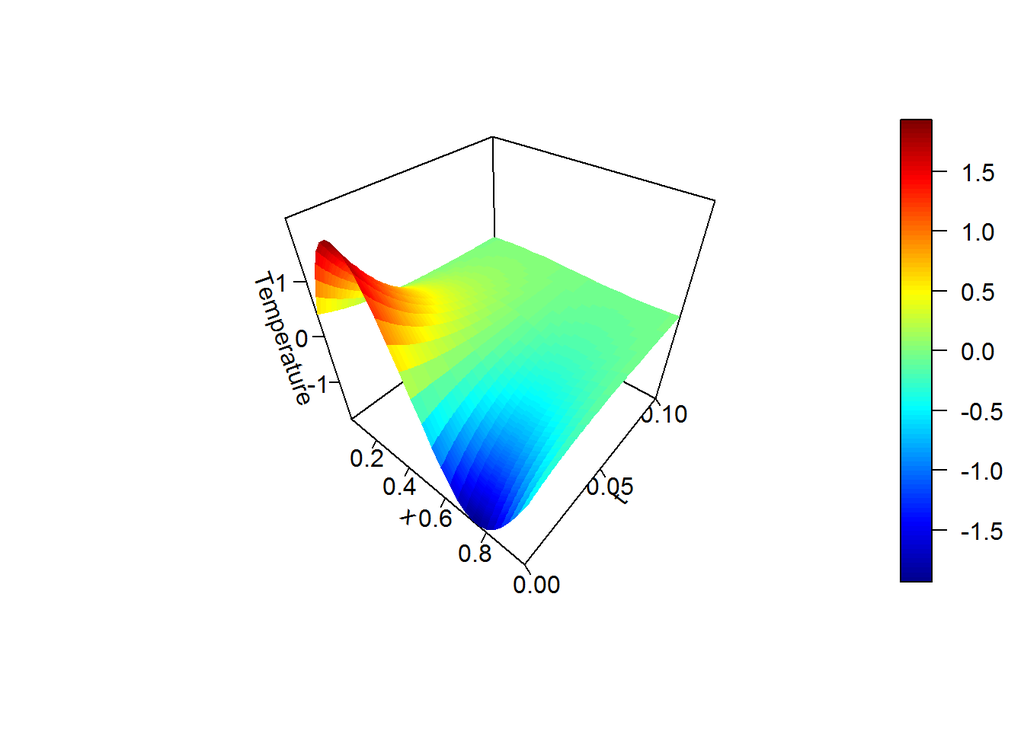

```r
library("plot3Drgl")
persp3D(x, t, Temperature,
        xlab="x", ylab="t", zlab="Temperature", # Provides axis labels
        ticktype="detailed", nticks=4) # Provides axis ticks
```

Let’s send the plot to a separate window again, and also turn on a light source to enhance the 3D effect.

```r
plotrgl(smooth=TRUE, lighting = TRUE)
```

## Exercises

1. Collect all the commands from above in your own R script file and make sure you can run the code from there and get the same solution.
2. Evolve the heat equation from two other initial conditions of your choosing.
3. Now explore the effect of different values of $K$ on the solution. Start with $K=0.5$. What do you observe? Does it agree with your expectation?
4. Next try $K=1.5$. What do you observe? Does it agree with your expectation?
5. To avoid the instability, change the size of the time step. How small does the time step have to be if you want to get a solution for $K=5$?
6. Modify the above file appropriately to solve the following initial boundary value problem
   $$u_{t}(x,t) = u_{xx}(x,t)-25 \sin(3\pi x), \quad
   0<x< 1, \quad 0<t<0.2;$$
   $$u(0, t) = u(1, t)=0, \quad u(x, 0) = -1.5\sin(2\pi x).$$
   Note that the generalisation of the forward-difference method to the non-homogeneous heat equation
   $$u_{t}=K \, u_{xx} + f(x),$$
   can be written as a matrix equation as
   $${\bf w}^{(j)}=A{\bf w}^{(j-1)}+\tau {\bf F} \quad \hbox{for} \quad j=1,2,\dots,$$
   where
   $${\bf F}=\left[
   \begin{array}{c}
   f_{x_1} \\ f_{x_2} \\ \vdots \\ \vdots \\ \vdots \\ f_{x_{N-1}}
   \end{array}\right]$$